# Mixed models using INLA

Joaquín Martínez-Minaya

2026-03-24

# 1 Introduction

This document demonstrates how to fit mixed-effects models using the **Integrated Nested Laplace Approximation (INLA)** methodology. We focus on a simulated dataset inspired by a study on respiratory rate measurements for patients with Chronic Obstructive Pulmonary Disease (COPD).

# 2 Medical Context

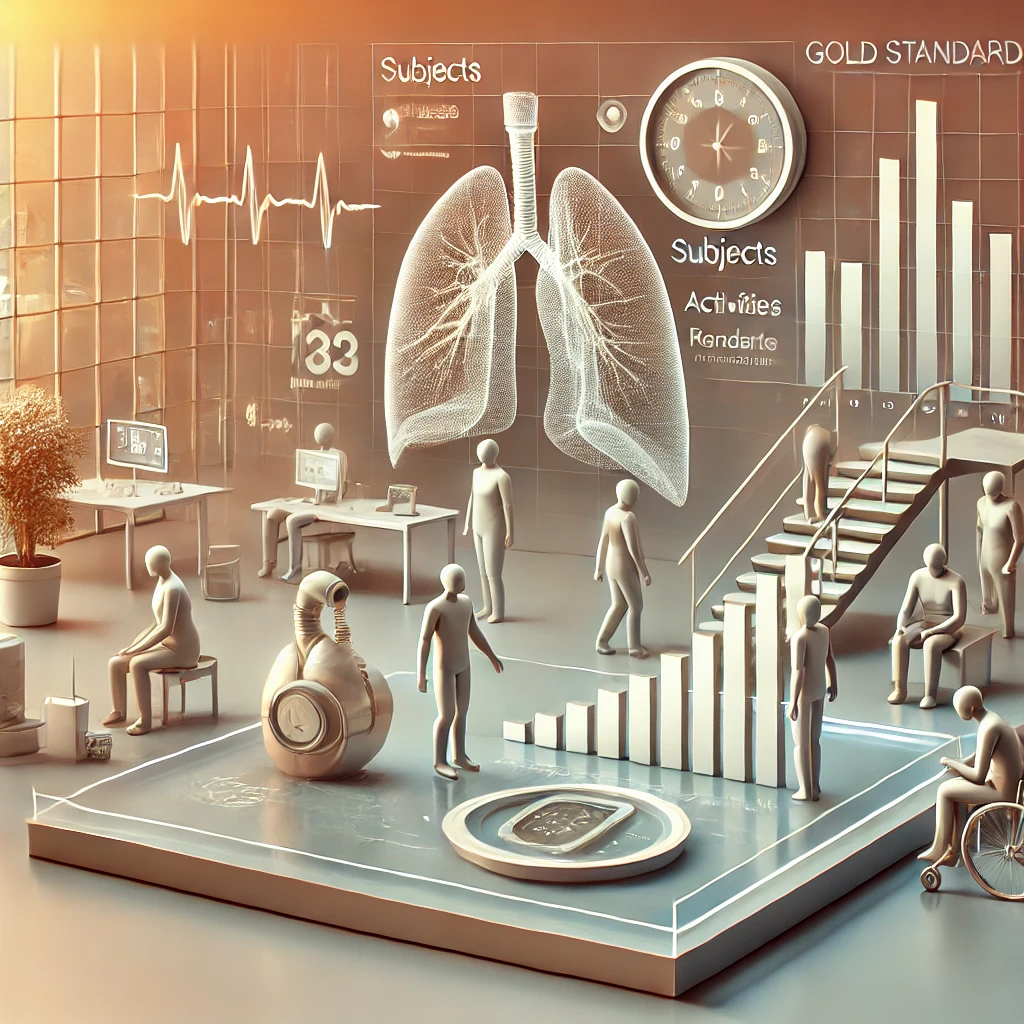

The example is based on a study investigating **agreement between devices** measuring respiratory rates in COPD patients. The goal was to assess how well various devices, including a **chest-band device**, agreed with a **gold standard device** (Oxycon mobile). Accurate measurement of respiratory rates is critical in managing **COPD**, as it provides insights into **disease severity** and **progression**.

Measurements were collected across **11 different activities** performed by **21 subjects**. These activities included sitting, lying, standing, slow walking, fast walking, sweeping, lifting objects, standing and walking, climbing stairs, treadmill walking on a flat surface, and treadmill walking with a 4% slope. The activities were chosen to reflect **real-life scenarios** and to represent a wide range of physical intensities, from **sedentary** to **vigorous activities**.

Each participant performed most of the activities, but not all, due to **individual limitations** or difficulties with certain tasks, such as walking on a treadmill. This led to an **unbalanced dataset**, where the number of observations varied between activities and individuals. For example, some activities, such as sitting, had repeated measurements per participant, while others had fewer replicates.

In this analysis, we account for **clustering within activities and replicates**, which can introduce dependencies in the data. The **hierarchical structure** of the dataset makes **mixed-effects models** particularly suitable, as they allow us to separate the variability attributable to activities, replicates, and devices, providing a more robust understanding of the data.

# 3 Dataset Description

The dataset consists of:

- `y`: The response variable, representing respiratory rate measured in **breaths per minute**.
- `device`: Indicates the **measurement device** used. It has two levels:
  1. **oxicon**: The gold standard device.
  2. **chest_band**: A wearable chest-band device.
- `replicate`: Represents the **replicated measurements** for each subject and activity. Replicates vary in number depending on the activity and subject.
- `act`: Refers to the **activity performed** during measurement. It includes **11 levels**:
  1. Sitting
  2. Lying
  3. Standing
  4. Slow walking
  5. Fast walking
  6. Sweeping
  7. Lifting objects
  8. Standing and walking
  9. Climbing stairs
  10. Treadmill (flat walking)
  11. Treadmill (4% slope)

Below is a summary of the dataset:

```r
data_copd <- readxl::read_xlsx("data_copd.xlsx")
data_copd$act <- as.factor(data_copd$act)
data_copd$replicate <- as.factor(data_copd$replicate)
data_copd$device <- as.factor(data_copd$device)
data_copd$device <- relevel(data_copd$device, ref = "oxicon")
head(data_copd)
```

| subj | y | replicate | act | device |
| --- | --- | --- | --- | --- |
| 1 | 38.19294 | 1 | Sitting | oxicon |
| 1 | 40.65189 | 2 | Sitting | oxicon |
| 1 | 36.00310 | 3 | Sitting | oxicon |
| 1 | 32.39582 | 1 | Lying | oxicon |
| 1 | 24.67484 | 2 | Lying | oxicon |
| 1 | 26.30875 | 3 | Lying | oxicon |

# 4 Fixed-Effects Models

## 4.1 Model 1: Device Differences Only

This model includes only the fixed effect of the device. It assumes no variability across activities or replicates.

```r
formula_device <- y ~ 1 + device

mod_device <- inla(
  formula_device,
  data = data_copd,
  family = "gaussian",
  control.fixed = list(prec = 0.01, prec.intercept = 0.01),
  control.compute = list(dic = TRUE, waic = TRUE)
)

summary(mod_device)
```

```
## Time used:
##     Pre = 0.452, Running = 0.827, Post = 0.179, Total = 1.46
## Fixed effects:
##                    mean    sd 0.025quant 0.5quant 0.975quant   mode kld
## (Intercept)      34.651 0.282     34.098   34.651     35.205 34.651   0
## devicechest_band  1.152 0.399      0.369    1.152      1.934  1.152   0
##
## Model hyperparameters:
##                                          mean    sd 0.025quant 0.5quant
## Precision for the Gaussian observations 0.018 0.001      0.017    0.018
##                                         0.975quant  mode
## Precision for the Gaussian observations      0.019 0.018
##
## Deviance Information Criterion (DIC) ...............: 9498.04
## Deviance Information Criterion (DIC, saturated) ....: 1390.11
## Effective number of parameters .....................: 2.99
##
## Watanabe-Akaike information criterion (WAIC) ...: 9498.07
## Effective number of parameters .................: 3.01
##
## Marginal log-Likelihood:  -4775.44
##  is computed
## Posterior summaries for the linear predictor and the fitted values are computed
## (Posterior marginals needs also 'control.compute=list(return.marginals.predictor=TRUE)')
```

## 4.2 Model 2: Device and Activity Differences

This model includes fixed effects for both the device and activity. It captures variability across different activities but assumes no clustering within replicates or activities.

```r
formula_device_activity <- y ~ 1 + device + act

mod_device_activity <- inla(
  formula_device_activity,
  data = data_copd,
  family = "gaussian",
  control.fixed = list(prec = 0.01, prec.intercept = 0.01),
  control.compute = list(dic = TRUE, waic = TRUE)
)

summary(mod_device_activity)
```

```
## Time used:
##     Pre = 0.383, Running = 0.339, Post = 0.401, Total = 1.12
## Fixed effects:
##                                mean    sd 0.025quant 0.5quant 0.975quant
## (Intercept)                  39.989 0.561     38.887   39.989     41.090
## devicechest_band              1.146 0.329      0.502    1.146      1.791
## actFast walking             -10.713 0.764    -12.211  -10.713     -9.214
## actLifting objects           -3.522 0.764     -5.020   -3.523     -2.024
## actLying                    -12.232 0.764    -13.729  -12.232    -10.733
## actSitting                   -4.851 0.764     -6.348   -4.851     -3.352
## actSlow walking              -4.963 0.764     -6.460   -4.963     -3.464
## actStanding                  -4.756 0.764     -6.253   -4.756     -3.257
## actStanding and walking     -11.095 0.764    -12.593  -11.095     -9.596
## actSweeping                   1.069 0.764     -0.429    1.068      2.567
## actTreadmill (4% slope)      -5.452 0.764     -6.950   -5.452     -3.953
## actTreadmill (flat walking)  -2.136 0.764     -3.633   -2.136     -0.637
##                                mode kld
## (Intercept)                  39.989   0
## devicechest_band              1.146   0
## actFast walking             -10.713   0
## actLifting objects           -3.523   0
## actLying                    -12.232   0
## actSitting                   -4.851   0
## actSlow walking              -4.963   0
## actStanding                  -4.756   0
## actStanding and walking     -11.095   0
## actSweeping                   1.068   0
## actTreadmill (4% slope)      -5.452   0
## actTreadmill (flat walking)  -2.136   0
##
## Model hyperparameters:
##                                          mean    sd 0.025quant 0.5quant
## Precision for the Gaussian observations 0.027 0.001      0.025    0.027
##                                         0.975quant  mode
## Precision for the Gaussian observations      0.029 0.027
##
## Deviance Information Criterion (DIC) ...............: 8971.89
## Deviance Information Criterion (DIC, saturated) ....: 1401.35
## Effective number of parameters .....................: 12.94
##
## Watanabe-Akaike information criterion (WAIC) ...: 8972.03
## Effective number of parameters .................: 12.95
##
## Marginal log-Likelihood:  -4534.86
##  is computed
## Posterior summaries for the linear predictor and the fitted values are computed
## (Posterior marginals needs also 'control.compute=list(return.marginals.predictor=TRUE)')
```